# PRACTICA PISA

Matias Corredoira

7/11/2020

```r
library(corrplot)
library(tidyverse)
library(caret)
library(magrittr)
library(knitr)
library(rsample)
library(PerformanceAnalytics)
library(leaps)
library(skimr)
library(gam)
library(ggcorrplot)
library(ISLR)
library(readr)
library(janitor)
library(imputeTS)
```

## Cargamos la base de datos y revisamos la base de datos

```r
pisa <- read_csv("pisasci2006.csv")
View(pisa)
```

## Realizamos una primera visión de los datos

```r
head(pisa)
```

```
## # A tibble: 6 x 11
##   Country Overall Issues Explain Evidence Interest Support Income Health    Edu
##   <chr>     <dbl>  <dbl>   <dbl>    <dbl>    <dbl>   <dbl>  <dbl>  <dbl>  <dbl>
## 1 Albania      NA     NA      NA       NA       NA      NA  0.599  0.886  0.716
## 2 Argent~     391    395     386      385      567     506  0.678  0.868  0.786
## 3 Austra~     527    535     520      531      465     487  0.826  0.965  0.978
## 4 Austria     511    505     516      505      507     515  0.835  0.944  0.824
## 5 Azerba~     382    353     412      344      612     542  0.566  0.78  NA
## 6 Belgium     510    515     503      516      503     492  0.831  0.935  0.868
## # ... with 1 more variable: HDI <dbl>
```

# Limpieza de datos

Escogemos las columnas del enunciado

Marcamos las columnas bien y pedimos que las muestre y así trabajarlas sin problema

```
## [1] "country"  "overall"  "interest" "support"  "income"   "health"   "edu"
## [8] "hdi"
```

Sumamos la cantidad de na por columna

```
## # A tibble: 1 x 8
##   country overall interest support income health   edu   hdi
##     <int>   <int>    <int>   <int>  <int>  <int> <int> <int>
## 1       0       8        8       8      4      4     6     6
```

Dada la existencia de demasiados valores NaN optamos por coger la media con na_mean desde imputeTS

### Realizamos una visión general de la base de nuevo que nos permitirá apreciar otros aspectos de la base de datos

Data summary

| Name | pisa |
| --- | --- |
| Number of rows | 65 |
| Number of columns | 8 |
| _______________________ |  |
| Column type frequency: |  |
| character | 1 |
| numeric | 7 |
| ________________________ |  |
| Group variables | None |

**Variable type: character**

| skim_variable | n_missing | complete_rate | min | max | empty | n_unique | whitespace |
| --- | --- | --- | --- | --- | --- | --- | --- |
| country | 0 | 1 | 4 | 24 | 0 | 65 | 0 |

**Variable type: numeric**

| skim_variable | n_missing | complete_rate | mean | sd | p0 | p25 | p50 | p75 | p100 | hist |
| --- | --- | --- | --- | --- | --- | --- | --- | --- | --- | --- |
| overall | 0 | 1 | 473.14 | 51.06 | 322.00 | 436.00 | 487.00 | 511.00 | 563.00 | ▁▂▂▇▃ |
| interest | 0 | 1 | 528.16 | 46.62 | 448.00 | 503.00 | 528.16 | 549.00 | 644.00 | ▆▇▇▃▂ |
| support | 0 | 1 | 512.18 | 24.40 | 447.00 | 497.00 | 512.18 | 527.00 | 569.00 | ▂▃▇▅▂ |
| income | 0 | 1 | 0.74 | 0.11 | 0.41 | 0.66 | 0.74 | 0.83 | 0.94 | ▁▂▆▇▅ |
| health | 0 | 1 | 0.89 | 0.06 | 0.72 | 0.84 | 0.89 | 0.94 | 0.99 | ▂▂▇▇▇ |
| edu | 0 | 1 | 0.80 | 0.11 | 0.54 | 0.74 | 0.80 | 0.87 | 0.99 | ▂▃▇▇▅ |
| hdi | 0 | 1 | 0.81 | 0.08 | 0.58 | 0.75 | 0.81 | 0.87 | 0.94 | ▁▃▆▇▆ |

### Representamos graficamente las variables de la base de datos

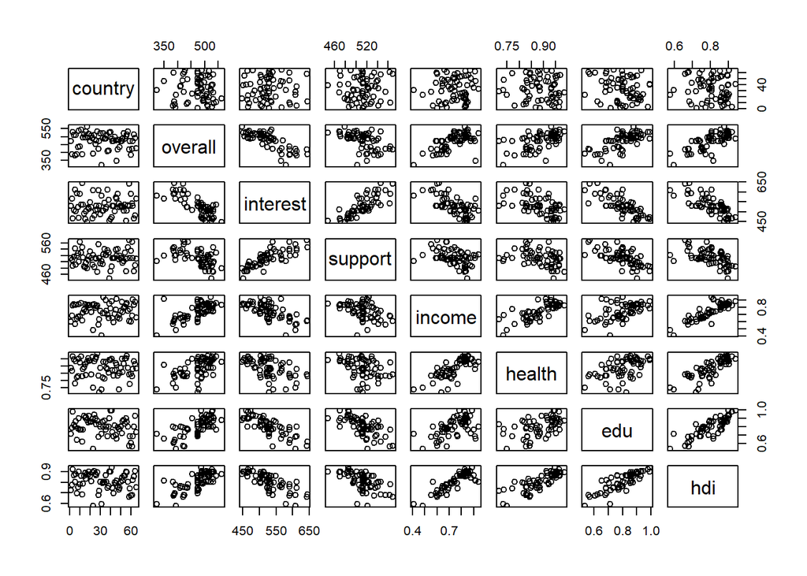

```r
plot(pisa)
```

## Realizamos un gráfico de correlaciones entre las distintas variables

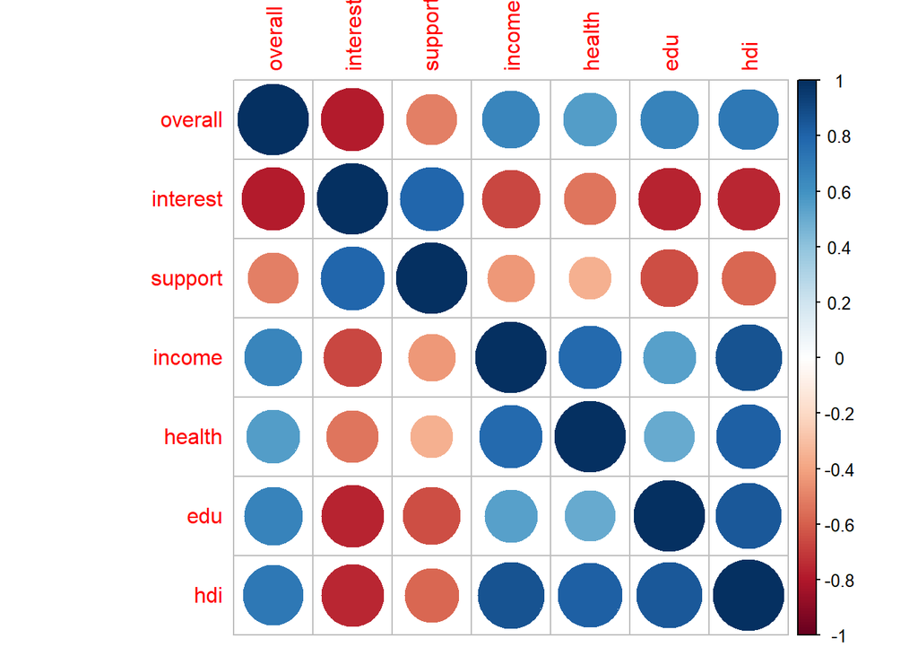

```r
corrplot(cor(pisa%>%
               select_at(vars(-country)),
             use = "complete.obs"),
         method = "circle")
```

Continuamos calculando los grados de libertad además de CV. Incluiremos las variables clave marcadas en el enunciado.

```
## Call:
## smooth.spline(x = pisa$interest, y = pisa$overall, cv = TRUE)
##
## Smoothing Parameter  spar= 0.9311547  lambda= 0.00465548 (13 iterations)
## Equivalent Degrees of Freedom (Df): 4.750171
## Penalized Criterion (RSS): 49516.15
## PRESS(l.o.o. CV): 916.1849
```

```
## Call:
## smooth.spline(x = pisa$support, y = pisa$overall, cv = TRUE)
##
## Smoothing Parameter  spar= 1.499961  lambda= 81.82485 (28 iterations)
## Equivalent Degrees of Freedom (Df): 2.001243
## Penalized Criterion (RSS): 68396.87
## PRESS(l.o.o. CV): 1996.088
```

```
## Call:
## smooth.spline(x = pisa$income, y = pisa$overall, cv = TRUE)
##
## Smoothing Parameter  spar= 1.080197  lambda= 0.007177517 (14 iterations)
## Equivalent Degrees of Freedom (Df): 4.244952
## Penalized Criterion (RSS): 66984.17
## PRESS(l.o.o. CV): 1293.909
```

```
## Call:
## smooth.spline(x = pisa$health, y = pisa$overall, cv = TRUE)
##
## Smoothing Parameter  spar= 1.499962  lambda= 44.19162 (28 iterations)
## Equivalent Degrees of Freedom (Df): 2.002844
## Penalized Criterion (RSS): 101821
## PRESS(l.o.o. CV): 1913.591
```

```
## Call:
## smooth.spline(x = pisa$hdi, y = pisa$overall, cv = TRUE)
##
## Smoothing Parameter  spar= 0.7604012  lambda= 0.0002060338 (11 iterations)
## Equivalent Degrees of Freedom (Df): 8.603228
## Penalized Criterion (RSS): 50163.52
## PRESS(l.o.o. CV): 1520.306
```

```
## Call:
## smooth.spline(x = pisa$edu, y = pisa$overall, cv = TRUE)
##
## Smoothing Parameter  spar= 1.49996  lambda= 52.19016 (28 iterations)
## Equivalent Degrees of Freedom (Df): 2.002385
## Penalized Criterion (RSS): 75381.88
## PRESS(l.o.o. CV): 1505.755
```

Nos da para cada variable en relación a sus grados de libertad: -interest=4.750171 -support:2.001243 -income:4.244952 -health:2.002844 -hdi:8.603228 -edu: 2.002385

# MODELOS GAM

Realizamos un primer modelo GAM para hacernos una idea aproximada.

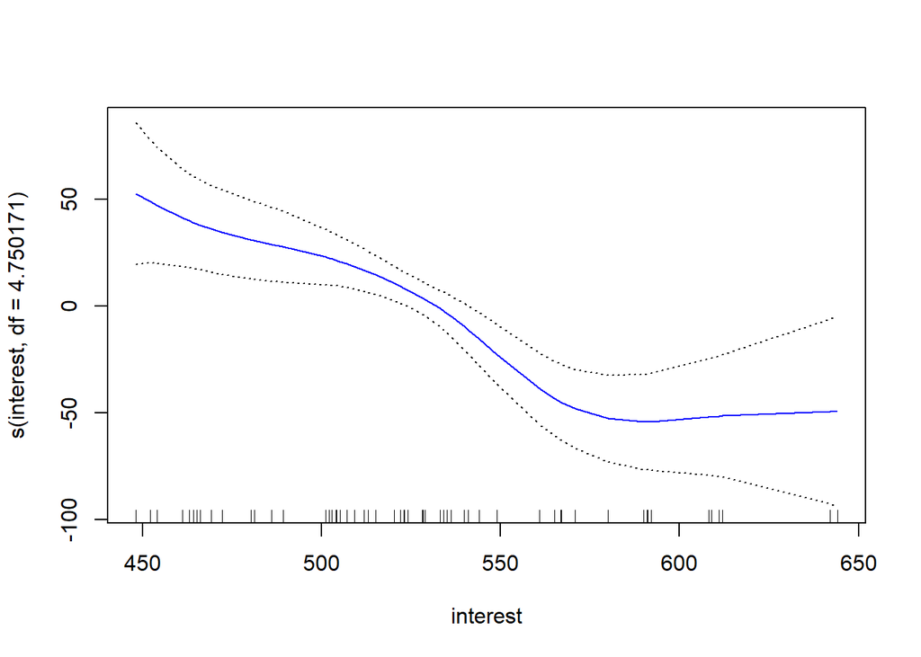

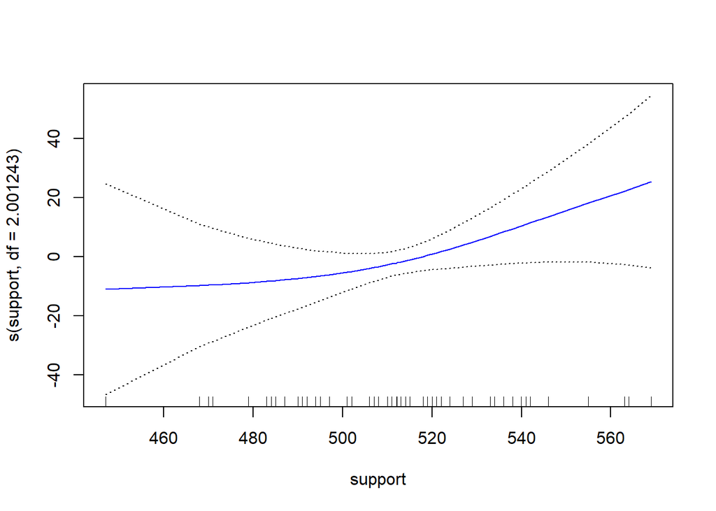

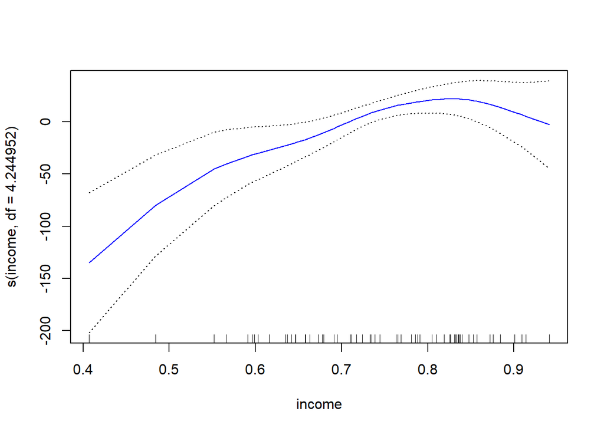

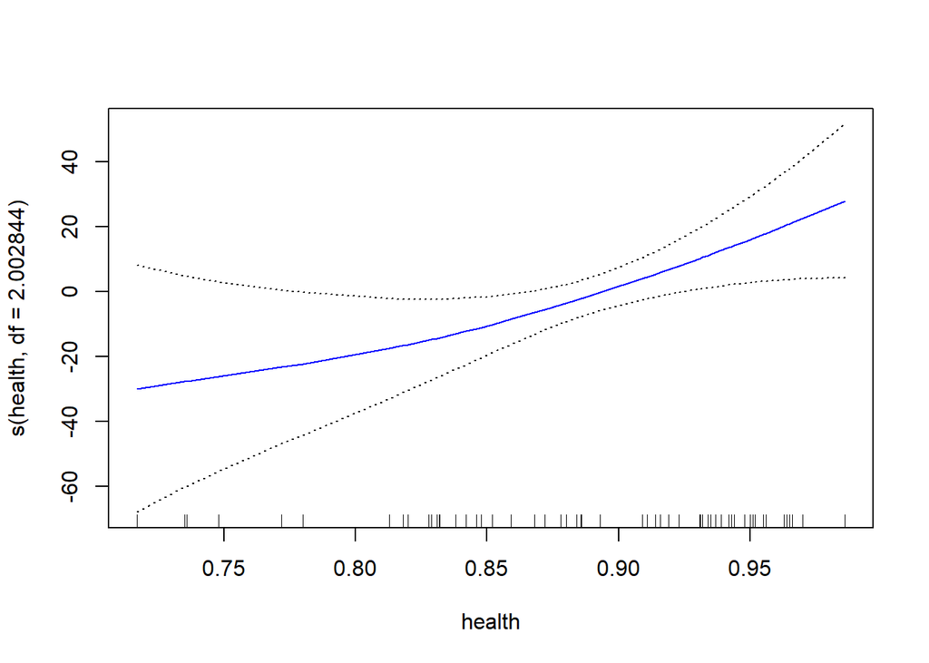

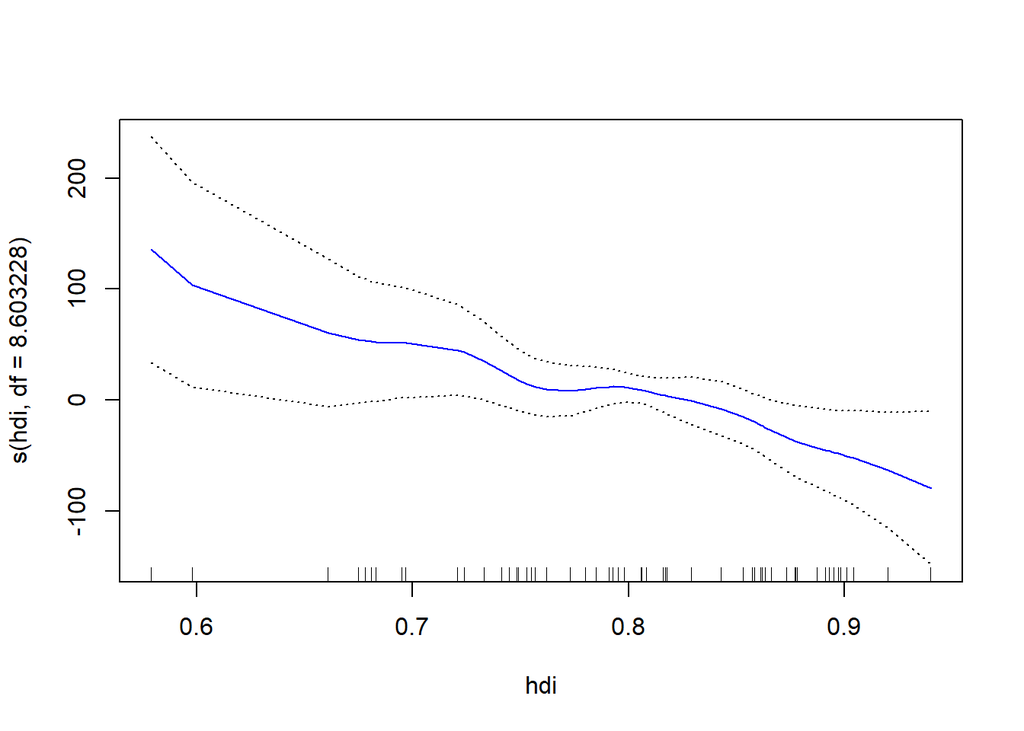

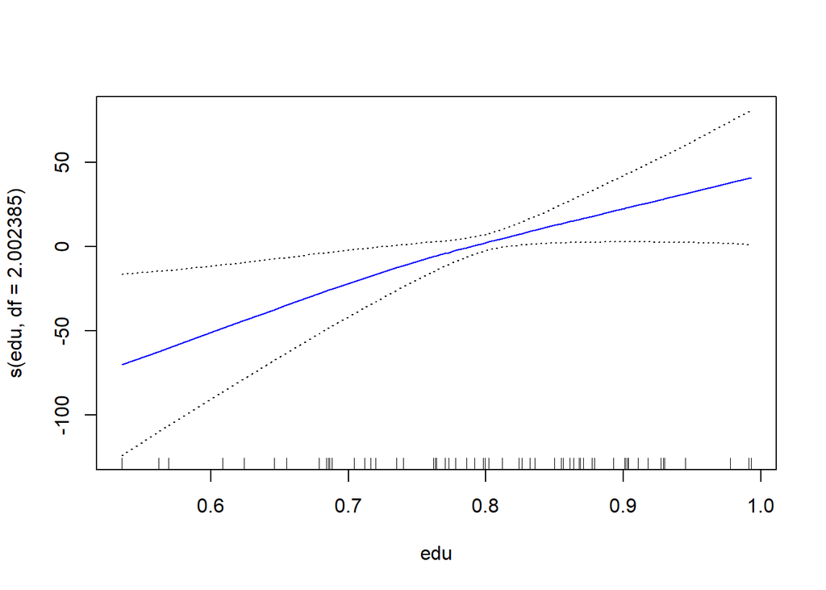

```r
gam_1 <- gam(overall ~ s(interest, df= 4.750171) + s(support, df = 2.001243) + s(income, df  = 4.244952) + s(health, df = 2.002844) + s(hdi, df=8.603228) + s(edu, df=2.002385) , data=pisa)
plot(gam_1,se=TRUE, col='blue')
```

```r
summary(gam_1)
```

```
##
## Call: gam(formula = overall ~ s(interest, df = 4.750171) + s(support,
##     df = 2.001243) + s(income, df = 4.244952) + s(health, df = 2.002844) +
##     s(hdi, df = 8.603228) + s(edu, df = 2.002385), data = pisa)
## Deviance Residuals:
##     Min      1Q  Median      3Q     Max
## -60.474  -8.204   3.146  11.663  51.433
##
## (Dispersion Parameter for gaussian family taken to be 596.1798)
##
##     Null Deviance: 166828.9 on 64 degrees of freedom
## Residual Deviance: 24082.78 on 40.3952 degrees of freedom
## AIC: 620.1379
##
## Number of Local Scoring Iterations: NA
##
## Anova for Parametric Effects
##                                Df Sum Sq Mean Sq  F value   Pr(>F)
## s(interest, df = 4.750171)  1.000  90386   90386 151.6092 2.96e-15 ***
## s(support, df = 2.001243)   1.000   2922    2922   4.9011  0.03255 *
## s(income, df = 4.244952)    1.000   4153    4153   6.9665  0.01174 *
## s(health, df = 2.002844)    1.000    743     743   1.2458  0.27095
## s(hdi, df = 8.603228)       1.000    126     126   0.2109  0.64852
## s(edu, df = 2.002385)       1.000   3541    3541   5.9399  0.01930 *
## Residuals                  40.395  24083     596
## ---
## Signif. codes:  0 '***' 0.001 '**' 0.01 '*' 0.05 '.' 0.1 ' ' 1
##
## Anova for Nonparametric Effects
##                            Npar Df Npar F   Pr(F)
## (Intercept)
## s(interest, df = 4.750171)     3.8 3.3651 0.02010 *
## s(support, df = 2.001243)      1.0 1.6195 0.21046
## s(income, df = 4.244952)       3.2 6.2325 0.00109 **
## s(health, df = 2.002844)       1.0 1.4044 0.24301
## s(hdi, df = 8.603228)          7.6 1.2305 0.30759
## s(edu, df = 2.002385)          1.0 1.7024 0.19939
## ---
## Signif. codes:  0 '***' 0.001 '**' 0.01 '*' 0.05 '.' 0.1 ' ' 1
```

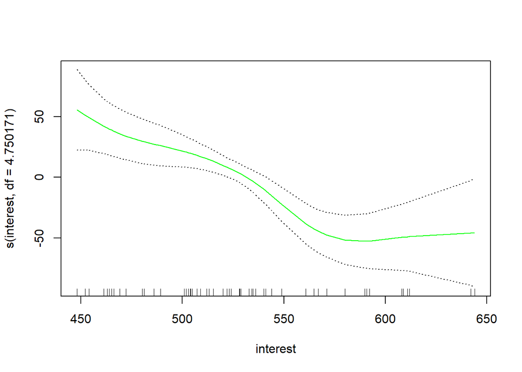

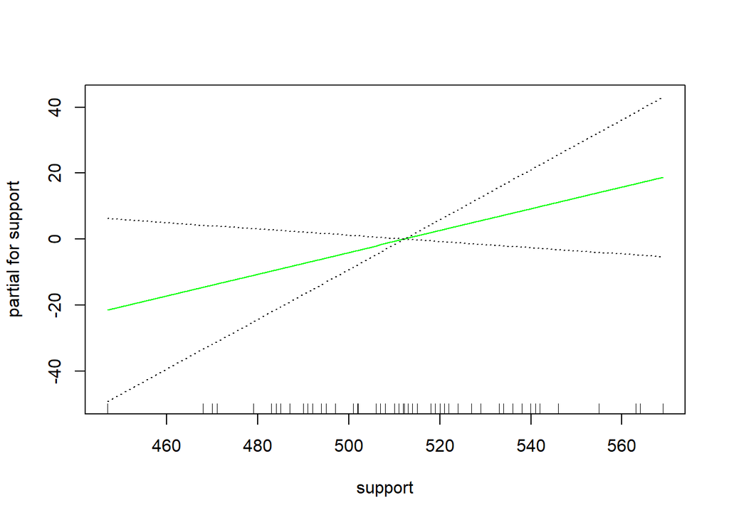

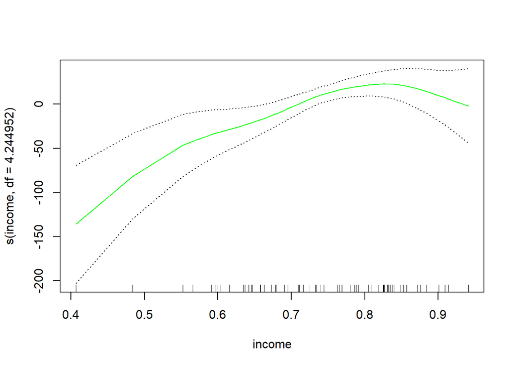

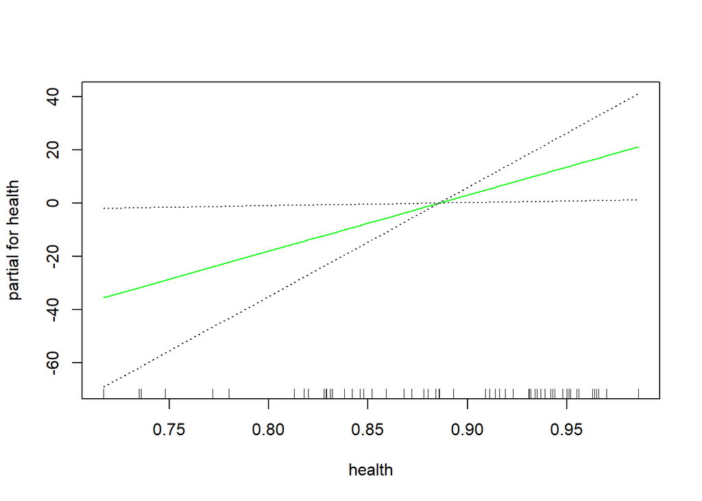

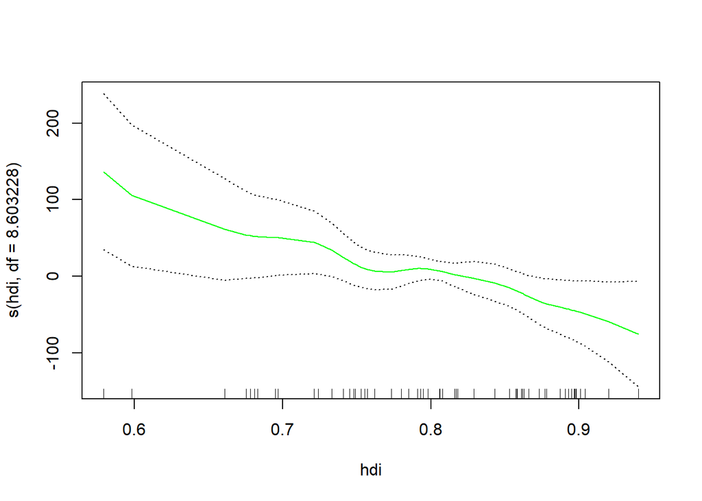

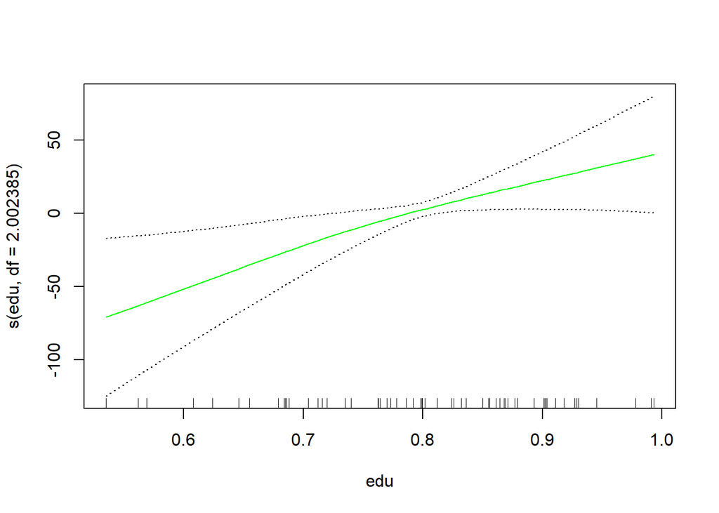

```r
gam_2 <- gam(overall ~ s(interest, df= 4.750171) + support + s(income, df  = 4.244952) + health + s(hdi, df=8.603228) + s(edu, df=2.002385) , data=pisa)
plot(gam_2,se=TRUE, col='green')
```